# Homework 4

Here is my submission for Homework 4.

Rhys Long (University of Massachusetts Amherst)  
04-09-2022

```r
library(alr4)
library(smss)
library(tidyverse)
library(ggplot2)
library(numbers)
library(dplyr)
```

##Question 1

#A

For backward elimination, the first variable to be deleted would be the number of bedrooms because it is the variable with the lowest level of statistical significance.

#B

For forward selection, the variable to be added first is Size because the p value is the smallest for size.

#C

The number of bedrooms is most likely correlated to house size, which is statistically significant. In other words, larger homes tend to have more bedrooms and smaller homes tend to have less bedrooms.

#D

Before evaluating which model is best for each critereon, I will first create four linear models to compare to each other. The first model has size as the only explanatory variable, the second model has size and newness as explanatory variables, the third model has every explanatory variable except for amount of bedrooms, and the fourth model has all four explanatory variables.

```r
data("house.selling.price.2")
Size_Only <- lm(formula = P ~ S, data = house.selling.price.2)
Size_New <- lm(formula = P ~ S + New, data = house.selling.price.2)
No_Bedrooms <- lm(formula = P ~ S + Ba + New, data = house.selling.price.2)
House_Regression <- lm(formula = P ~ S + Be + Ba + New, data = house.selling.price.2)
```

For the r squared model, the four variable regression equation is most suitable because the largest r squared value is associated with the four variable equation.

```r
summary(Size_Only)$r.squared
```

```
[1] 0.807866
```

```r
summary(Size_New)$r.squared
```

```
[1] 0.8483699
```

```r
summary(No_Bedrooms)$r.squared
```

```
[1] 0.8681361
```

```r
summary(House_Regression)$r.squared
```

```
[1] 0.868863
```

For the adjusted r squared model, the three variable regression equation is the most suitable because the largest adjusted r squared value is associated with the third regression equation.

```r
#Adjusted R Squared Model: 3 Variable
summary(Size_Only)$adj.r.squared
```

```
[1] 0.8057546
```

```r
summary(Size_New)$adj.r.squared
```

```
[1] 0.8450003
```

```r
summary(No_Bedrooms)$adj.r.squared
```

```
[1] 0.8636912
```

```r
summary(House_Regression)$adj.r.squared
```

```
[1] 0.8629022
```

```r
#Press Model: Use the 3 variable model
PRESS <- function(Linear_Model) {
    pr <- residuals(Linear_Model)/(1 - lm.influence(Linear_Model)$hat)
    sum(pr^2)
}

#One Variable
PRESS(Size_Only)
```

```
[1] 38203.29
```

```r
#Two Variables
PRESS(Size_New)
```

```
[1] 31066
```

```r
#Three Variables
PRESS(No_Bedrooms)
```

```
[1] 27860.05
```

```r
#Four Variables
PRESS(House_Regression)
```

```
[1] 28390.22
```

```r
#AIC Model: Three Variable
#One Variable
AIC(Size_Only)
```

```
[1] 820.1439
```

```r
#Two Variables
AIC(Size_New)
```

```
[1] 800.1262
```

```r
#Three Variables
AIC(No_Bedrooms)
```

```
[1] 789.1366
```

```r
#Four Variables
AIC(House_Regression)
```

```
[1] 790.6225
```

```r
#BIC Model
#One Variable
BIC(Size_Only)
```

```
[1] 827.7417
```

```r
#Two Variables
BIC(Size_New)
```

```
[1] 810.2566
```

```r
#Three Variables
BIC(No_Bedrooms)
```

```
[1] 801.7996
```

```r
#Four Variables
BIC(House_Regression)
```

```
[1] 805.8181
```

#E

Out of the 5 models, I would say r squared is my least favorite because the r squared model did not return the same results as the other three models, but other than that, I have no preference.

##Question 2 #A

```r
data("trees")
tree_regression <- lm(formula=Volume~Girth+Height, data=trees)
summary(tree_regression)
```

```
Call:
lm(formula = Volume ~ Girth + Height, data = trees)

Residuals:
    Min      1Q  Median      3Q     Max
-6.4065 -2.6493 -0.2876  2.2003  8.4847

Coefficients:
            Estimate Std. Error t value Pr(>|t|)
(Intercept) -57.9877     8.6382  -6.713 2.75e-07 ***
Girth         4.7082     0.2643  17.816  < 2e-16 ***
Height        0.3393     0.1302   2.607   0.0145 *
---
Signif. codes:  0 '***' 0.001 '**' 0.01 '*' 0.05 '.' 0.1 ' ' 1

Residual standard error: 3.882 on 28 degrees of freedom
Multiple R-squared:  0.948, Adjusted R-squared:  0.9442
F-statistic:   255 on 2 and 28 DF,  p-value: < 2.2e-16
```

For the trees regression model, the regression equation is y=-57.9877+4.7082x1+0.3393x2.

#B

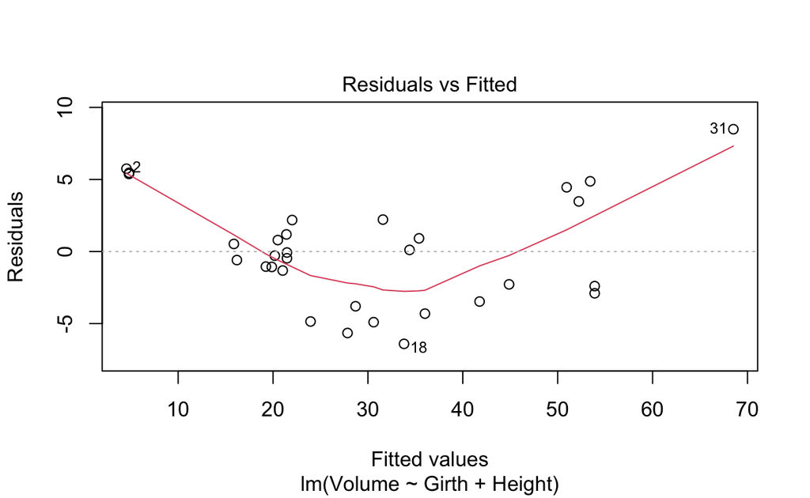

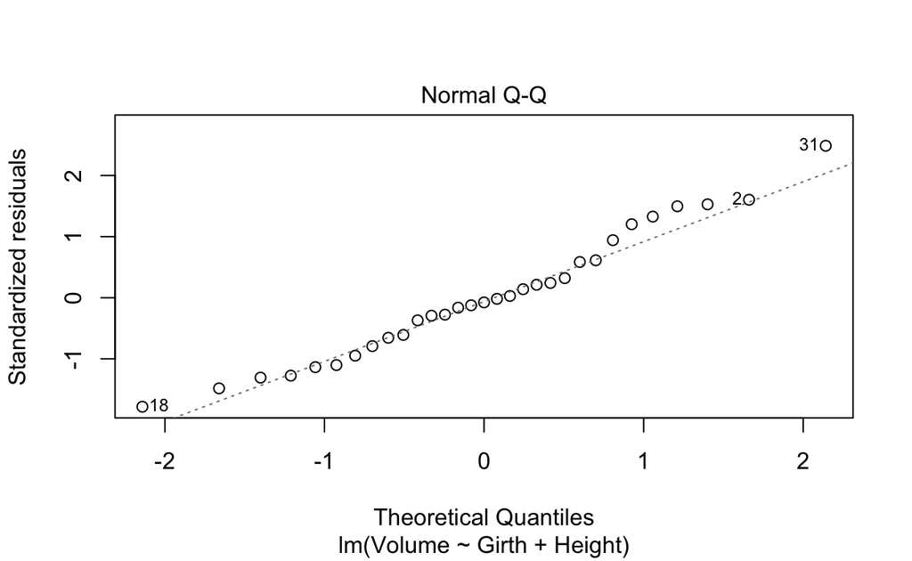

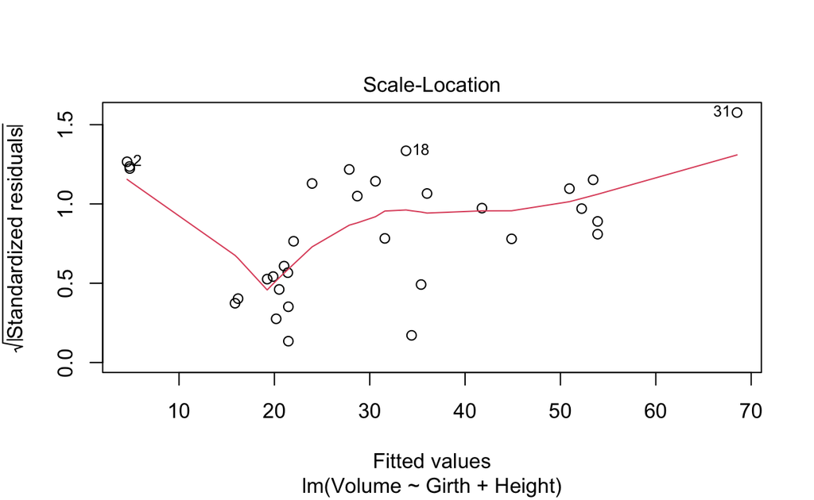

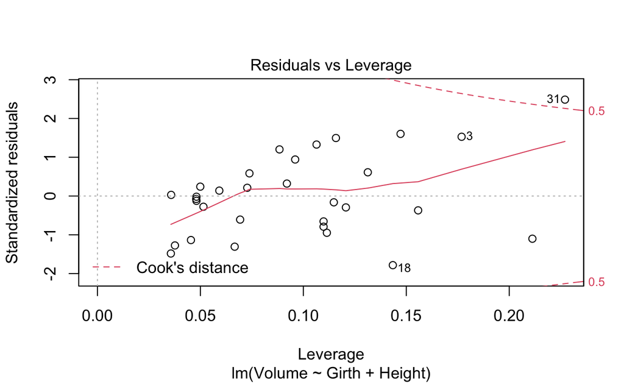

```r
plot(tree_regression)
```

##Question 3

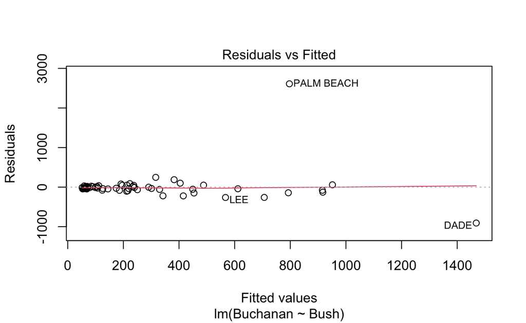

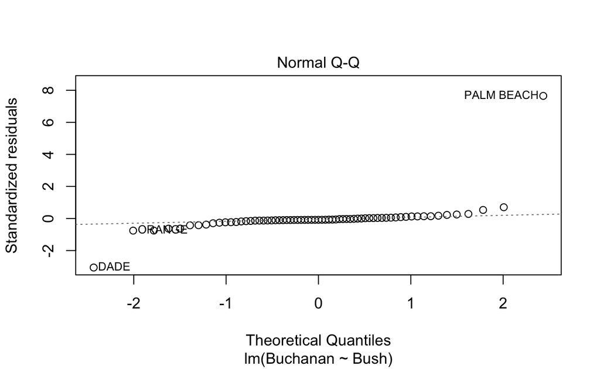

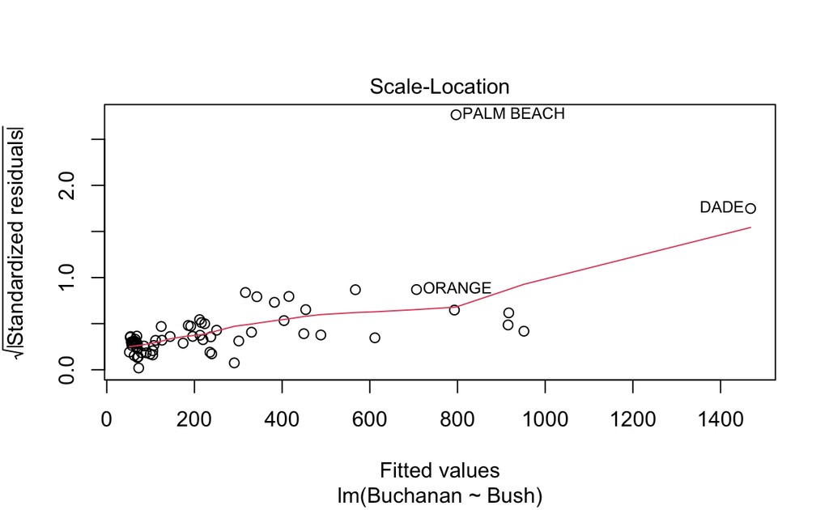

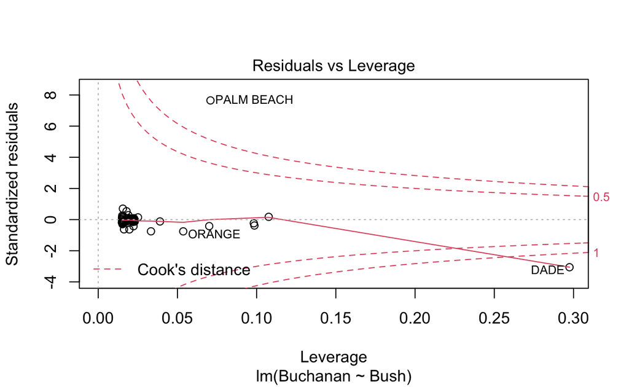

```r
data(florida)
florida_regression <- lm(formula=Buchanan~Bush, data=florida)
plot(florida_regression)
```

Based on the diagnostic plots it is extremely safe to conclude that the palm beach county data is an outlier. Because the Palm Beach point is far off from all the other points in all of the models.

##Project

#Overview

For my final project, I propose using the data I collected from a project I didn’t get to complete last semester. The topic of my final project pertains to the issues of polarization and media bias detection. Over the course of the 2010’s the issue of polarization increased in prevalence as access to smartphones increased in prevalence due to how social media algorithms personalize news feeds. The purpose of my project is to look for insights about how people consume and perceive their news feeds and gain an understanding of how polarization manifests.

#Research Questions

Q1: Do people judge news reliability based on which news station is broadcasting the content or on whether they’re hearing what they want to hear?

Q2: Does college education increase or decrease polarization?

#Hypotheses

H1: People care the most about hearing whether they’re hearing what they want to hear in their news than they do about who they’re hearing their news from.

H2: College-educated people will have less polarized results than non-college educated people.

#Experiment

For my experiment, I had my subjects read one of four possible news articles about presidential approval ratings. The titles of the articles were “CNN Poll: Joe Biden’s Approval Ratings Continue To Sink”, “CNN Poll: Donald Trump’s Approval Ratings Continue To Sink”, “FOX News: Joe Biden’s Approval Ratings Continue To Sink”, and “FOX News: Donald Trump’s Approval Ratings Continue To Sink”. After skimming the article, the subjects were asked “How reliable is this source?” and “How well does this source cover all sides?”. The questions were asked in a random order, but in the dataset from the survey, the order in which the subjects answered the questions was not indicated

#Operationalization

For question responses, the scale for each question was 0-10, with zero indicating that the source is unreliable and ten indicating that the source is reliable. For the sake of quantitative analysis, I also decided to assign a quantitative scale to the subjects’ political party. Symbolic of liberal being the left and conservative being the right, I assigned -3 to strongly liberal subjects, -2 to liberal subjects, -1 to independents with liberal leanings, 0 to independents without leanings, 1 to independents with conservative leanings, 2 to conservative subjects, and 3 to strongly conservative subjects.

#Data Cleaning

```r
##Data Cleaning
Project <- read.csv("/Users/rhyslong/Desktop/Project_Dataset.csv") %>%
  select(Q104:Q105, Q18.1:Q18.2, Q18.3:Q18.4_8, Q18.5, Q18.6:Q18.8, Q18.9:Q18.12, PresidentFirst:NewsOrg) %>%
  slice(1, 3:210) %>%
  rename("Question_1"=Q104,
         "Question_2"=Q105,
         "Vaccinated"=Q18.1,
         "Education"=Q18.2,
         "Marital Status"=Q18.3,
         "Black"=Q18.4_1,
         "Indigenous_American_or_Alaskan_Native"=Q18.4_2,
         "Asian"=Q18.4_3,
         "Hispanic_or_Latino"=Q18.4_4,
         "Middle_Eastern"=Q18.4_5,
         "White"=Q18.4_6,
         "West_Indian"=Q18.4_7,
         "No_Disclosure"=Q18.4_8,
         "Gender"=Q18.5,
         "Age"=Q18.6,
         "Income"=Q18.7,
         "Party"=Q18.8,
         "Republican"=Q18.9,
         "Democrat"=Q18.10,
         "Closer_To"=Q18.11,
         "Election"=Q18.12) %>%
  slice(2:209) %>%
  arrange(Question_1) %>%
  arrange(Question_2) %>%
  slice(6:208) %>%
  mutate(Republican=case_when(
    Republican=="Not very strong Republican"~"Not_Strong",
    Republican=="Strong Republican"~"Strong",
  )) %>%
  mutate(Democrat=case_when(
    Democrat=="Not very strong Democrat"~"Not_Strong",
    Democrat=="Strong Democrat"~"Strong",
  )) %>%
  mutate(Closer_To=case_when(
    Closer_To=="Democrat"~"Leaning_Democrat",
    Closer_To=="Republican"~"Leaning_Republican",
  )) %>%
  unite("Specifics", Republican:Democrat, remove = TRUE) %>%
  unite("Specifics", Specifics:Closer_To, remove = TRUE) %>%
  mutate(Specifics=case_when(
    Specifics=="NA_NA_Leaning_Democrat" ~ "Leaning_Democrat",
    Specifics=="NA_NA_Leaning_Republican"~"Leaning_Republican",
    Specifics=="NA_Strong_NA"~"Strong",
    Specifics=="Strong_NA_NA"~"Strong",
  )) %>%
  unite("Specific_Party", Party:Specifics, remove = FALSE) %>%
  mutate(Party=case_when(
    Specific_Party=="Democrat_Strong" ~ -3,
    Specific_Party=="Democrat_NA" ~ -2,
    Specific_Party=="Independent_Leaning_Democrat" ~ -1,
    Specific_Party=="Independent_NA" ~ 0,
    Specific_Party=="Other_NA" ~ 0,
    Specific_Party== "No Preference_NA" ~ 0,
    Specific_Party=="Independent_Leaning_Republican"~ 1,
    Specific_Party=="Republican_NA" ~ 2,
    Specific_Party=="Republican_Strong"~3,
  )) %>%
  mutate(Black=case_when(
    Black=="African American or Black"~TRUE)) %>%
  mutate(Indigenous_American_or_Alaskan_Native=case_when(
    Indigenous_American_or_Alaskan_Native=="American Indian or Alaska Native"~TRUE)) %>%
  mutate(Asian=case_when(
    Asian=="Asian"~TRUE)) %>%
  mutate(Hispanic_or_Latino=case_when(
    Hispanic_or_Latino=="Hispanic or Latino"~TRUE)) %>%
  mutate(Middle_Eastern=case_when(
    Middle_Eastern=="Middle Eastern"~TRUE)) %>%
  mutate(White=case_when(
    White=="White"~TRUE)) %>%
  mutate(West_Indian=case_when(
    West_Indian=="Other"~TRUE)) %>%
  mutate(No_Disclosure=case_when(
    No_Disclosure=="Prefer not to answer"~TRUE)) %>%
  pivot_longer(Black:No_Disclosure, names_to = "Race", values_to = "Remove") %>%
  filter(Remove==TRUE) %>%
  select(Question_1:Race)%>%
  mutate(Question_1=case_when(
    Question_1 == "0: Highly Unreliable" ~ 0,
    Question_1 == "1" ~ 1,
    Question_1 == "2" ~ 2,
    Question_1 == "3" ~ 3,
    Question_1 == "4" ~ 4,
    Question_1 == "5: Neither Reliable or Unreliable" ~ 5,
    Question_1 == "6" ~ 6,
    Question_1 == "7" ~ 7,
    Question_1 == "8" ~ 8,
    Question_1 == "9" ~ 9,
    Question_1 == "10: Highly Reliable" ~ 10,
  )) %>%
  mutate(Question_2=case_when(
    Question_2 == "0: Not Well At All" ~ 0,
    Question_2 == "1" ~ 1,
    Question_2 == "2" ~ 2,
    Question_2 == "3" ~ 3,
    Question_2 == "4" ~ 4,
    Question_2 == "5: Moderately Well" ~ 5,
    Question_2 == "6" ~ 6,
    Question_2 == "7" ~ 7,
    Question_2 == "8" ~ 8,
    Question_2 == "9" ~ 9,
    Question_2 == "10: Extremely Well" ~ 10,
  )) %>%
  unite("President_Criticized", PresidentFirst:PresidentLast) %>%
  mutate(President_Criticized=case_when(
    President_Criticized=="Joe_Biden"~"Biden",
    President_Criticized=="Donald_Trump"~"Trump",
  )) %>%
  rename("News_Source"=NewsOrg) %>%
  unite("Article", News_Source:President_Criticized, remove = FALSE) %>%
  mutate(Specifics=case_when(
    Specifics == NA ~ "Regular",
    Specifics == "Strong"~"Strong",
    Specifics == "Leaning_Democrat"~"Leaning_Democrat",
    Specifics == "Leaning_Republican"~"Leaning_Republican",
  )) %>%
  pivot_longer(Question_1:Question_2, names_to = "Question", values_to = "Response") %>%
  mutate(Question=case_when(
    Question=="Question_1"~1,
    Question=="Question_2"~2,
  )) %>%
  mutate(Education=case_when(
    Education=="Associate's Degree"~"Undergraduate",
    Education=="Bachelor's Degree"~"Undergraduate",
    Education=="High School"~"High School",
    Education=="High School (Not Completed)"~"High School",
    Education=="Master's or PhD"~"Graduate",
    Education=="Some College coursework"~"Undergraduate",
  ))%>%
  select(Article:News_Source, Education, Party, Question, Response)

#Main Variables
Project$College <- ifelse(Project$Education=="High School", "No","Yes")

#Final Data
Data <- select(Project, Party:College, Article)
CNN_Biden <- filter(Data, Article=="CNN_Biden") %>%
  select(Party:Response, College)
CNN_Trump <- filter(Data, Article=="CNN_Trump") %>%
  select(Party:Response, College)
FOX_Biden <- filter(Data, Article=="FOX_Biden") %>%
  select(Party:Response, College)
FOX_Trump <- filter(Data, Article=="FOX_Trump") %>%
  select(Party:Response, College)
```

#Hypothesis 1 Regression

```r
CNN_Biden_Regression_1 <- lm(formula=Response~Party, data=CNN_Biden)
summary(CNN_Biden_Regression_1)
```

```
Call:
lm(formula = Response ~ Party, data = CNN_Biden)

Residuals:
    Min      1Q  Median      3Q     Max
-5.5954 -1.5155  0.4845  1.4046  3.4845

Coefficients:
            Estimate Std. Error t value Pr(>|t|)
(Intercept)  6.75515    0.25148  26.862   <2e-16 ***
Party        0.07990    0.09842   0.812    0.419
---
Signif. codes:  0 '***' 0.001 '**' 0.01 '*' 0.05 '.' 0.1 ' ' 1

Residual standard error: 2.155 on 100 degrees of freedom
Multiple R-squared:  0.006547,  Adjusted R-squared:  -0.003387
F-statistic: 0.6591 on 1 and 100 DF,  p-value: 0.4188
```

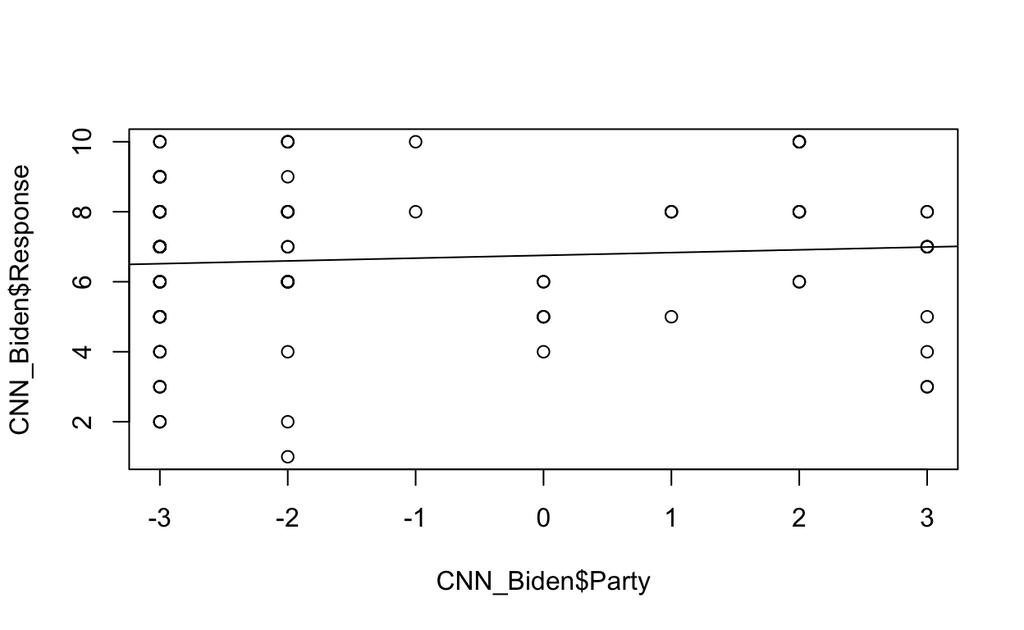

```r
plot(x=CNN_Biden$Party, y=CNN_Biden$Response)
abline(CNN_Biden_Regression_1)
```

```r
CNN_Trump_Regression_1 <- lm(formula=Response~Party, data=CNN_Trump)
summary(CNN_Trump_Regression_1)
```

```
Call:
lm(formula = Response ~ Party, data = CNN_Trump)

Residuals:
    Min      1Q  Median      3Q     Max
-4.9567 -0.9939  0.1921  1.4262  4.8945

Coefficients:
            Estimate Std. Error t value Pr(>|t|)
(Intercept)  5.95670    0.20687  28.795  < 2e-16 ***
Party       -0.61706    0.08544  -7.222 6.17e-11 ***
---
Signif. codes:  0 '***' 0.001 '**' 0.01 '*' 0.05 '.' 0.1 ' ' 1

Residual standard error: 2.177 on 114 degrees of freedom
Multiple R-squared:  0.3139,    Adjusted R-squared:  0.3079
F-statistic: 52.16 on 1 and 114 DF,  p-value: 6.168e-11
```

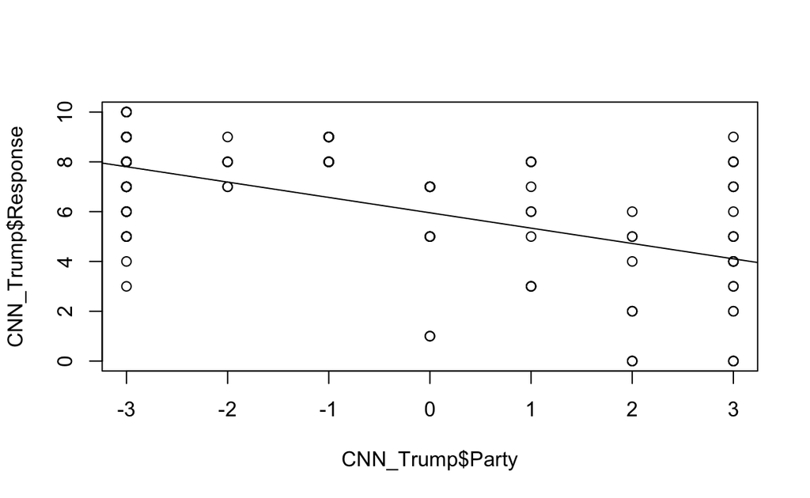

```r
plot(x=CNN_Trump$Party, y=CNN_Trump$Response)
abline(CNN_Trump_Regression_1)
```

In my CNN Trump subject group, the regression equation is y=5.95670-0.61706x. The fact that the slope is negative suggests that liberal subjects were more likely to rate this article as reliable than conservative subjects. Moreover, the difference is statistically significant because p-score is 6.17e-11.

```r
FOX_Biden_Regression_1 <- lm(formula=Response~Party, data=FOX_Biden)
summary(FOX_Biden_Regression_1)
```

```
Call:
lm(formula = Response ~ Party, data = FOX_Biden)

Residuals:
    Min      1Q  Median      3Q     Max
-6.0173 -1.7317  0.2681  2.2324  4.2681

Coefficients:
            Estimate Std. Error t value Pr(>|t|)
(Intercept)   6.1600     0.4589  13.423   <2e-16 ***
Party         0.1427     0.1839   0.776     0.44
---
Signif. codes:  0 '***' 0.001 '**' 0.01 '*' 0.05 '.' 0.1 ' ' 1

Residual standard error: 2.765 on 96 degrees of freedom
Multiple R-squared:  0.006231,  Adjusted R-squared:  -0.004121
F-statistic: 0.6019 on 1 and 96 DF,  p-value: 0.4398
```

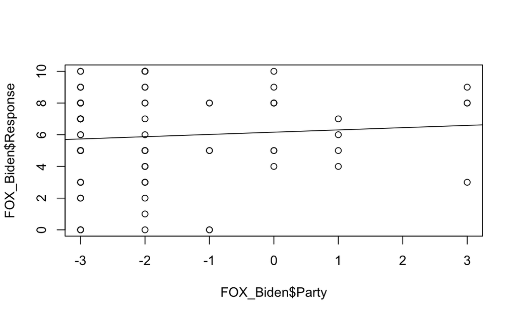

```r
plot(x=FOX_Biden$Party, y=FOX_Biden$Response)
abline(FOX_Biden_Regression_1)
```

```r
FOX_Trump_Regression_1 <- lm(formula=Response~Party, data=FOX_Trump)
summary(FOX_Trump_Regression_1)
```

```
Call:
lm(formula = Response ~ Party, data = FOX_Trump)

Residuals:
    Min      1Q  Median      3Q     Max
-6.6502 -1.4522  0.3498  1.3498  4.0098

Coefficients:
            Estimate Std. Error t value Pr(>|t|)
(Intercept)  6.25424    0.27041  23.129   <2e-16 ***
Party       -0.13200    0.09874  -1.337    0.184
---
Signif. codes:  0 '***' 0.001 '**' 0.01 '*' 0.05 '.' 0.1 ' ' 1

Residual standard error: 2.44 on 98 degrees of freedom
Multiple R-squared:  0.01791,   Adjusted R-squared:  0.007888
F-statistic: 1.787 on 1 and 98 DF,  p-value: 0.1844
```

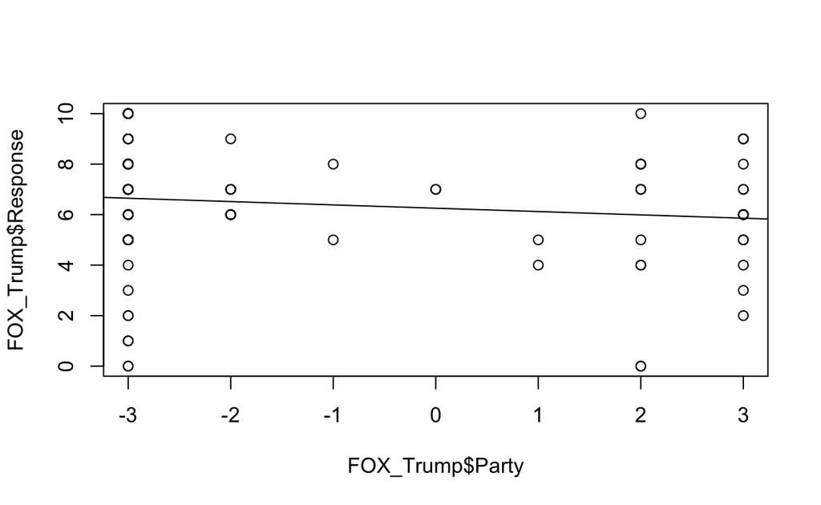

```r
plot(x=FOX_Trump$Party, y=FOX_Trump$Response)
abline(FOX_Trump_Regression_1)
```

In my FOX Trump subject group, the regression equation is y=6.25424-0.13200x. The fact that the slope is negative suggests that liberal subjects were more likely to rate this article as reliable than conservative subjects. In other words, liberal subjects seem to care more about the fact that Trump is being bashed than about the fact that the news is coming from FOX. Moreover, the p-score is 0.184, which may not be statistically significant, but it is more statistically significant than the 0.44 and 0.419 p scores from other articles. Below, I provide a visual summary of the results of all four subject groups.

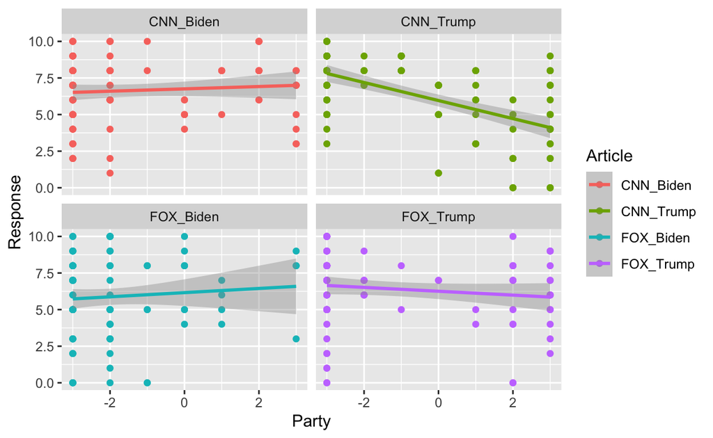

```r
ggplot(Data, aes(x=Party, y=Response, color=Article)) + geom_point() + geom_smooth(method="lm") + facet_wrap(vars(Article))
```

Based on the results above, I can conclude that subjects care more about hearing what they want to hear in the news than who they’re hearing their news from, but I also can’t make conclusions because the majority of my results lacked statistical significance. Next, I will be looking at the results pertaining to the impact of college education on polarization.

#Hypothesis 2 Regression

```r
CNN_Biden_Regression_2 <- lm(formula=Response~Party+College, data=CNN_Biden)
summary(CNN_Biden_Regression_2)
```

```
Call:
lm(formula = Response ~ Party + College, data = CNN_Biden)

Residuals:
    Min      1Q  Median      3Q     Max
-4.6604 -1.5568  0.3396  1.3223  4.8923

Coefficients:
            Estimate Std. Error t value Pr(>|t|)
(Intercept)  5.24601    0.76846   6.827 7.06e-10 ***
Party        0.06915    0.09697   0.713   0.4775
CollegeYes   1.62180    0.78185   2.074   0.0406 *
---
Signif. codes:  0 '***' 0.001 '**' 0.01 '*' 0.05 '.' 0.1 ' ' 1

Residual standard error: 2.12 on 99 degrees of freedom
Multiple R-squared:  0.04793,   Adjusted R-squared:  0.02869
F-statistic: 2.492 on 2 and 99 DF,  p-value: 0.08794
```

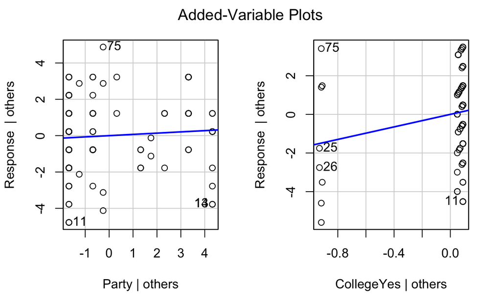

```r
avPlots(CNN_Biden_Regression_2)
```

In the CNN Biden group, the regression when college education is an added factor is y=5.24601+0.06915x1+1.62180x2. The fact that the first slope is positive suggests that conservative subjects perceive the source as more reliable than liberal subjects and the fact that the second slope is positive suggests that college educated people are more likely to perceive the source as reliable than subjects without college education. Moreover, the p-score for the college education slope is statistically significant, suggesting that college education does have an impact on perceptions of media bias.

```r
CNN_Trump_Regression_2 <- lm(formula=Response~Party+College, data=CNN_Trump)
summary(CNN_Trump_Regression_2)
```

```
Call:
lm(formula = Response ~ Party + College, data = CNN_Trump)

Residuals:
    Min      1Q  Median      3Q     Max
-4.9864 -0.9722  0.1836  1.4036  4.8436

Coefficients:
            Estimate Std. Error t value Pr(>|t|)
(Intercept)  5.79749    0.55348  10.475  < 2e-16 ***
Party       -0.60999    0.08875  -6.873 3.64e-10 ***
CollegeYes   0.18892    0.60878   0.310    0.757
---
Signif. codes:  0 '***' 0.001 '**' 0.01 '*' 0.05 '.' 0.1 ' ' 1

Residual standard error: 2.185 on 113 degrees of freedom
Multiple R-squared:  0.3145,    Adjusted R-squared:  0.3024
F-statistic: 25.92 on 2 and 113 DF,  p-value: 5.429e-10
```

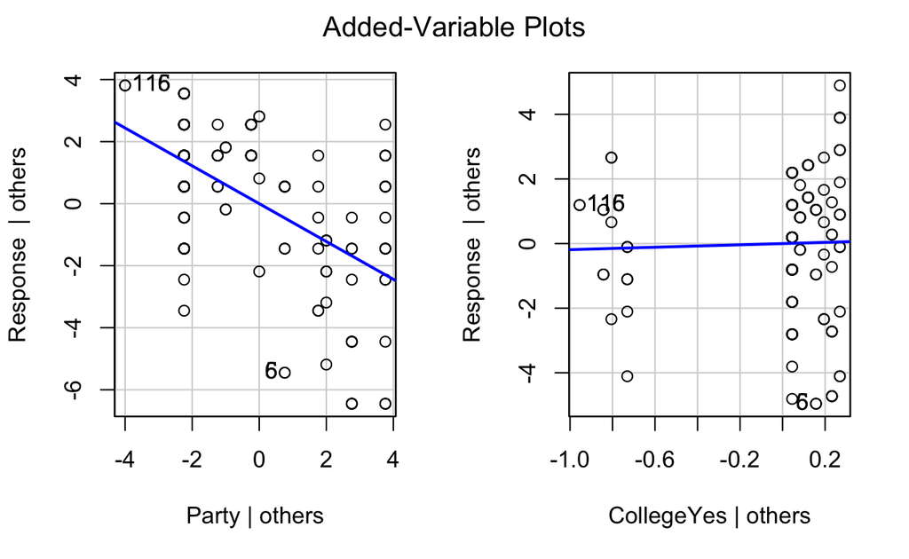

```r
avPlots(CNN_Trump_Regression_2)
```

In the CNN Trump group, the regression when college education is an added factor is y=5.79749-0.60999x1+0.18892x2. The fact that the first slope is negative suggests that liberal subjects perceive the source as more reliable than conservative subjects and the fact that the second slope is positive suggests that college educated people are more likely to perceive the source as reliable than subjects without college education. Moreover, the p-score for the political party slope is statistically significant, suggesting that even if college education does have an impact on perceptions of media bias, at the end of the day, people still have biases associated with preferred political stances.

```r
FOX_Biden_Regression_2 <- lm(formula=Response~Party+College, data=FOX_Biden)
summary(FOX_Biden_Regression_2)
```

```
Call:
lm(formula = Response ~ Party + College, data = FOX_Biden)

Residuals:
    Min      1Q  Median      3Q     Max
-5.9154 -1.6398  0.2384  2.1871  4.2897

Coefficients:
            Estimate Std. Error t value Pr(>|t|)
(Intercept)   7.5513     1.3847   5.453 3.91e-07 ***
Party         0.1025     0.1876   0.546    0.586
CollegeYes   -1.5333     1.4400  -1.065    0.290
---
Signif. codes:  0 '***' 0.001 '**' 0.01 '*' 0.05 '.' 0.1 ' ' 1

Residual standard error: 2.763 on 95 degrees of freedom
Multiple R-squared:  0.01795,   Adjusted R-squared:  -0.002724
F-statistic: 0.8683 on 2 and 95 DF,  p-value: 0.423
```

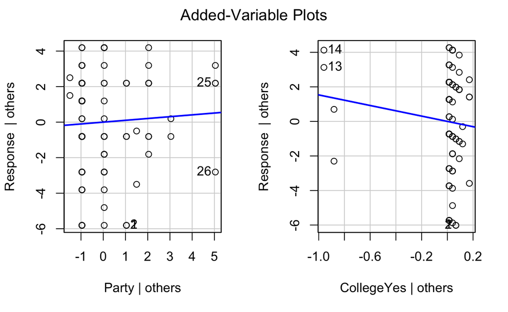

```r
avPlots(FOX_Biden_Regression_2)
```

In the FOX Biden group, the regression when college education is an added factor is y=7.5513+0.1025x1-1.5333x2. The fact that the first slope is positive suggests that conservative subjects perceive the source as more reliable than liberal subjects and the fact that the second slope is negative suggests that college educated people are less likely to perceive the source as reliable than subjects without college education. However, neither p-score suggests statistical significance.

```r
FOX_Trump_Regression_2 <- lm(formula=Response~Party+College, data=FOX_Trump)
summary(FOX_Trump_Regression_2)
```

```
Call:
lm(formula = Response ~ Party + College, data = FOX_Trump)

Residuals:
    Min      1Q  Median      3Q     Max
-6.7527 -1.3573  0.2473  1.4879  3.8122

Coefficients:
            Estimate Std. Error t value Pr(>|t|)
(Intercept)  4.12900    0.97647   4.228 5.33e-05 ***
Party       -0.11300    0.09709  -1.164    0.247
CollegeYes   2.28475    1.01039   2.261    0.026 *
---
Signif. codes:  0 '***' 0.001 '**' 0.01 '*' 0.05 '.' 0.1 ' ' 1

Residual standard error: 2.391 on 97 degrees of freedom
Multiple R-squared:  0.06709,   Adjusted R-squared:  0.04785
F-statistic: 3.488 on 2 and 97 DF,  p-value: 0.03446
```

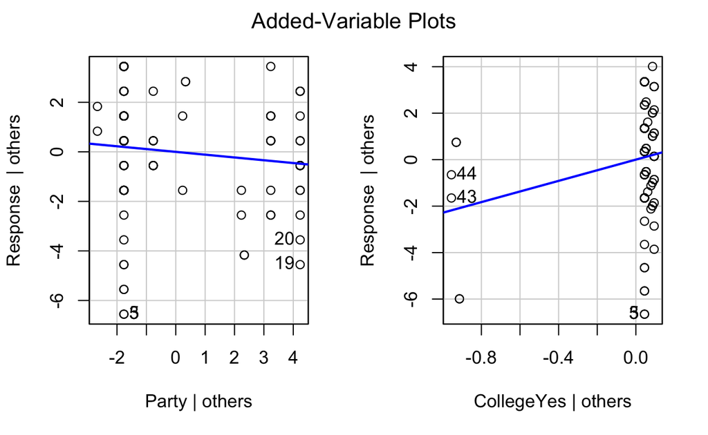

```r
avPlots(FOX_Trump_Regression_2)
```

In the FOX Trump group, the regression when college education is an added factor is y=4.12900-0.11300x1+2.28475x2. The fact that the first slope is negative suggests that liberal subjects perceive the source as more reliable than conservative subjects and the fact that the second slope is positive suggests that college educated people are more likely to perceive the source as reliable than subjects without college education. Moreover, the p-score for the college education slope is statistically significant, suggesting that college education does have an impact on perceptions of media bias.

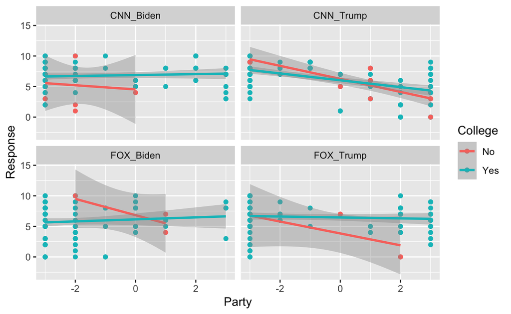

```r
ggplot(Data, aes(x=Party, y=Response, color=College))+geom_point()+geom_smooth(method="lm")+facet_wrap(vars(Article))
```

In the visuals above, the line for college educated subjects is consistently less steep than the line for subjects without a college education. This suggests not only that college education decreases polarization, but also that college educated people are less likely to judge news reliability on whether they’re hearing what they want to hear.